# DACSS 697D Post 5

text as data

homework

Assignment 5 for DACSS 697D Course ‘Text as Data’: “Representing Texts”

Kristina Becvar https://www.kristinabecvar.com  
2022-04-05

# Getting Started

I have begun pulling the data I will be analyzing for my final project in the course. So far, I have pulled a collection of articles by month beginning January 2020 through December 2021 from the New York Times using their “article search” API for the search query “Afghanistan”. I have not limited my search by any filter at this time. However, I have been limited in that the article search API for the New York Times does not pull the entire article; rather, I have been able to pull the abstract/summary, lead paragraph, and snippet for each article as well as the keywords, authors, sections, and url. In addition, I can get the article titles for both the print and online versions of the article.

Loading the data from my collection phase:

```r
#load data
load("afghanistan.articles.table.RData")
afghanistan_lead <- read.csv("lead.paragraph.table.csv")
afghanistan_articles <- as.data.frame(afghanistan_lead)
```

Creating a corpus from the data:

```r
afghanistan_corpus <- corpus(afghanistan_articles)
afghanistan_summary <- summary(afghanistan_corpus)
head(afghanistan_corpus)
```

```
Corpus consisting of 6 documents and 11 docvars.
text1 :
"“He’s a Rambo version of the same story Trump has been telli..."

text2 :
"Sign up for our Watching newsletter to get recommendations o..."

text3 :
"At least 87 pro-government forces and 12 civilians were kill..."

text4 :
"TOKYO — Carlos Ghosn was aided in his escape from Japan by a..."

text5 :
"You’re reading this week’s At War newsletter. Sign up here t..."

text6 :
"He changed the shape of the Syrian civil war and tightened I..."
```

This time I’m going to add an indicator of the search term used for this corpus, in case I want to add more search terms in the future.

```r
#of the search term used
afghanistan_articles$term <- "Afghanistan"
# add the metadata
docvars(afghanistan_corpus, field = "term") <- afghanistan_articles$term
```

And create a dataframe of tokens:

```r
afghanistan_tokens <- tokens(afghanistan_corpus)
print(afghanistan_tokens)
```

```
Tokens consisting of 3,442 documents and 12 docvars.
text1 :
 [1] "\""      "He's"    "a"       "Rambo"   "version" "of"
 [7] "the"     "same"    "story"   "Trump"   "has"     "been"
[ ... and 28 more ]

text2 :
 [1] "Sign"            "up"              "for"
 [4] "our"             "Watching"        "newsletter"
 [7] "to"              "get"             "recommendations"
[10] "on"              "the"             "best"
[ ... and 14 more ]

text3 :
 [1] "At"             "least"          "87"
 [4] "pro-government" "forces"         "and"
 [7] "12"             "civilians"      "were"
[10] "killed"         "in"             "Afghanistan"
[ ... and 158 more ]

text4 :
 [1] "TOKYO"  "-"      "Carlos" "Ghosn"  "was"    "aided"  "in"
 [8] "his"    "escape" "from"   "Japan"  "by"
[ ... and 44 more ]

text5 :
 [1] "You're"     "reading"    "this"       "week's"     "At"
 [6] "War"        "newsletter" "."          "Sign"       "up"
[11] "here"       "to"
[ ... and 13 more ]

text6 :
 [1] "He"        "changed"   "the"       "shape"     "of"
 [6] "the"       "Syrian"    "civil"     "war"       "and"
[11] "tightened" "Iran's"
[ ... and 48 more ]

[ reached max_ndoc ... 3,436 more documents ]
```

Now I’ll use quanteda to generate the document-feature matrix from the corpus object:

```r
afghanistan_dfm <- dfm(tokens(afghanistan_corpus))
afghanistan_dfm
```

```
Document-feature matrix of: 3,442 documents, 14,101 features (99.75% sparse) and 12 docvars.
       features
docs    " he's a rambo version of the same story trump
  text1 2    1 1     1       1  1   4    1     1     1
  text2 0    0 0     0       0  0   1    0     0     0
  text3 0    0 3     0       0  1   9    0     0     0
  text4 0    0 2     0       0  1   4    0     0     0
  text5 0    0 0     0       0  0   0    0     0     0
  text6 0    0 0     0       0  4   5    0     0     0
[ reached max_ndoc ... 3,436 more documents, reached max_nfeat ... 14,091 more features ]
```

This is a bit more difficult to navigate given that my data is not subdivided by chapter, rather there is an individual record for each of the 3,442 articles. Perhaps I will do some pre-processing as part of the matrix creation. Going Removing punctuation, numbers, capitalization, and stopwords as a comparison:

```r
# create the dfm
afghanistan_dfm <- tokens(afghanistan_corpus,
                                    remove_punct = TRUE,
                                    remove_numbers = TRUE) %>%
                           dfm(tolower=TRUE) %>%
                           dfm_remove(stopwords('english'))
# find out a quick summary of the dfm
afghanistan_dfm
```

```
Document-feature matrix of: 3,442 documents, 13,624 features (99.84% sparse) and 12 docvars.
       features
docs    rambo version story trump telling deep state trying screw
  text1     1       1     1     1       1    1     1      1     1
  text2     0       0     0     0       0    0     0      0     0
  text3     0       0     0     0       0    0     0      0     0
  text4     0       0     0     0       0    0     0      0     0
  text5     0       0     0     0       0    0     0      0     0
  text6     0       0     0     0       0    0     0      0     0
       features
docs    media
  text1     1
  text2     0
  text3     0
  text4     0
  text5     0
  text6     0
[ reached max_ndoc ... 3,436 more documents, reached max_nfeat ... 13,614 more features ]
```

With the more simplified version, I can look at the most frequent terms (features), starting with the top 20 frequent terms.

```r
topfeatures(afghanistan_dfm, 20)
```

```
afghanistan   president     taliban  washington    american
        963         624         507         460         436
      kabul         new      united    military         u.s
        404         388         378         375         364
       said       biden         war      states         get
        358         357         352         343         302
     afghan         two         one      people       trump
        290         280         257         247         236
```

I would really like to be able to look at the most frequent terms by month/year/section, but have not been able to get that command to run properly yet.

```r
#world_words <- as.vector(colSums(afghanistan_dfm) == afghanistan_dfm$section.name["World"])
#head(colnames(afghanistan_dfm)[world_words])
```

## Looking at word frequencies

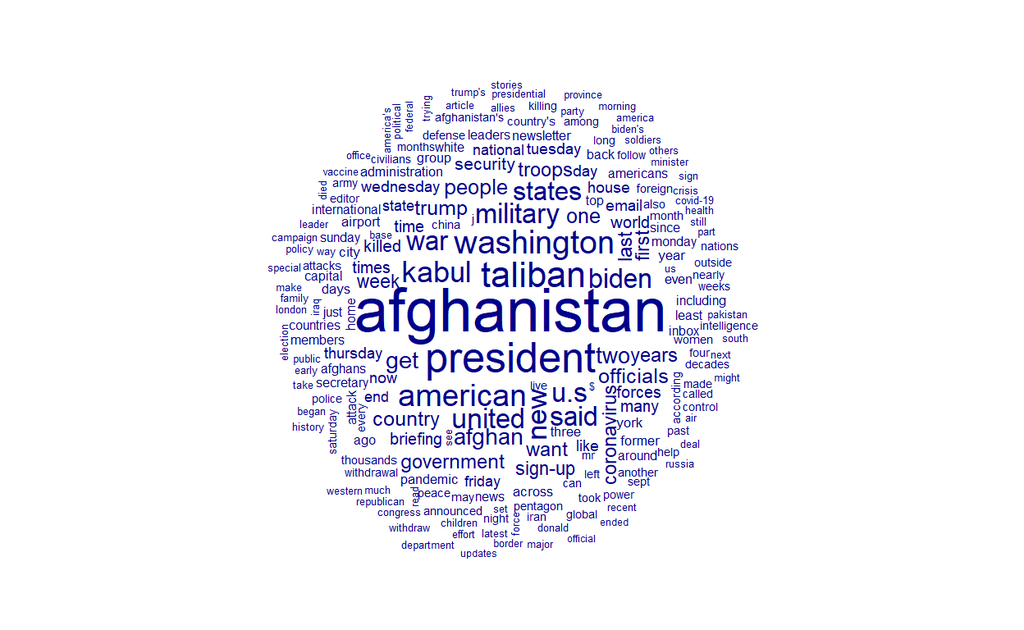

```r
# programs often work with random initializations, yielding different outcomes.
# we can set a standard starting point though to ensure the same output.
set.seed(1234)
# draw the wordcloud
textplot_wordcloud(afghanistan_dfm, min_count = 50, random_order = FALSE)
```

```r
# first, we need to create a word frequency variable and the rankings
word_counts <- as.data.frame(sort(colSums(afghanistan_dfm),dec=T))
colnames(word_counts) <- c("Frequency")
word_counts$Rank <- c(1:ncol(afghanistan_dfm))
head(word_counts)
```

```
            Frequency Rank
afghanistan       963    1
president         624    2
taliban           507    3
washington        460    4
american          436    5
kabul             404    6
```

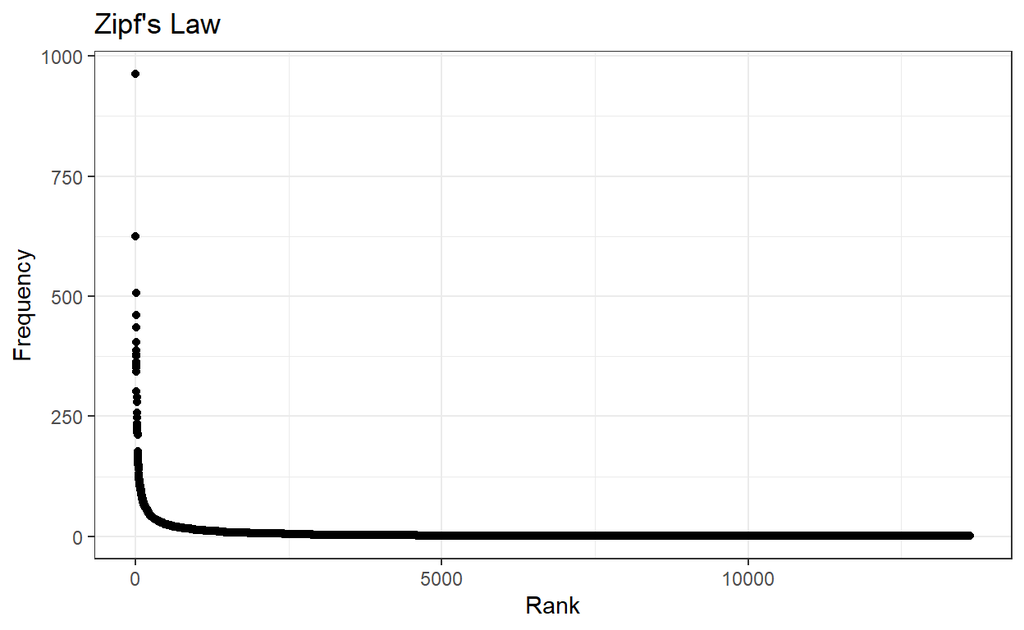

```r
ggplot(word_counts, mapping = aes(x = Rank, y = Frequency)) +
  geom_point() +
  labs(title = "Zipf's Law", x = "Rank", y = "Frequency") +
  theme_bw()
```

```r
# trim based on the overall frequency (i.e., the word counts) with a max at the top "non-gibberish" term.
smaller_dfm <- dfm_trim(afghanistan_dfm, max_termfreq = 1043)
# trim based on the proportion of documents that the feature appears in; here,
# the feature needs to appear in more than 5% of documents (articles)
smaller_dfm <- dfm_trim(smaller_dfm, min_docfreq = 0.05, docfreq_type = "prop")
smaller_dfm
```

```
Document-feature matrix of: 3,442 documents, 31 features (90.95% sparse) and 12 docvars.
       features
docs    trump people get afghanistan week taliban one afghan two
  text1     1      1   0           0    0       0   0      0   0
  text2     0      0   1           0    0       0   0      0   0
  text3     0      0   0           1    2       2   1      1   1
  text4     0      0   0           0    0       0   0      0   0
  text5     0      0   1           0    0       0   0      0   0
  text6     0      0   0           0    0       0   0      0   1
       features
docs    american
  text1        0
  text2        0
  text3        1
  text4        1
  text5        0
  text6        1
[ reached max_ndoc ... 3,436 more documents, reached max_nfeat ... 21 more features ]
```

Now I can take a look again at the wordcloud and word frequency metrics:

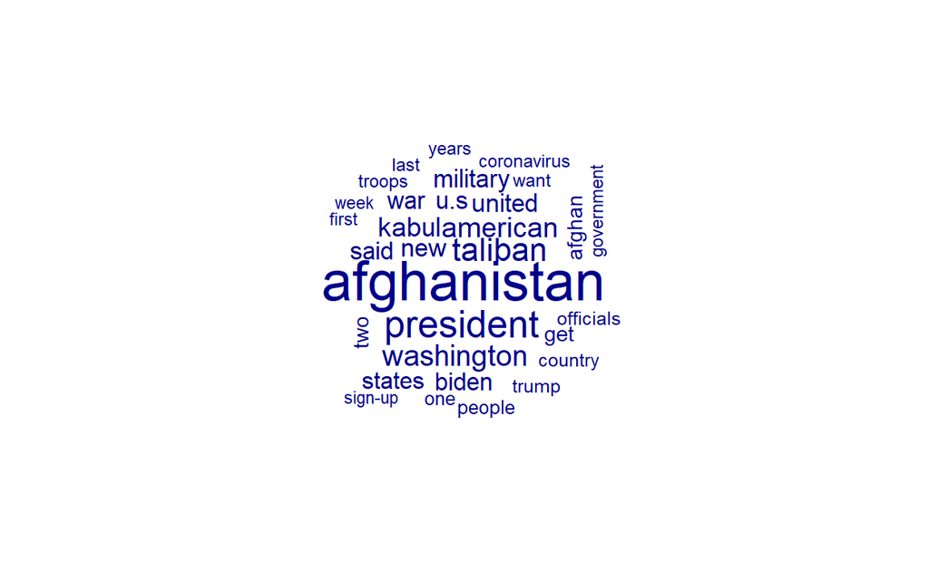

```r
# programs often work with random initializations, yielding different outcomes.
# we can set a standard starting point though to ensure the same output.
set.seed(1234)
# draw the wordcloud
textplot_wordcloud(smaller_dfm, min_count = 1, random_order = FALSE)
```

```r
# first, we need to create a word frequency variable and the rankings
word_counts <- as.data.frame(sort(colSums(smaller_dfm),dec=T))
colnames(word_counts) <- c("Frequency")
word_counts$Rank <- c(1:ncol(smaller_dfm))
word_counts
```

```
            Frequency Rank
afghanistan       963    1
president         624    2
taliban           507    3
washington        460    4
american          436    5
kabul             404    6
new               388    7
united            378    8
military          375    9
u.s               364   10
said              358   11
biden             357   12
war               352   13
states            343   14
get               302   15
afghan            290   16
two               280   17
one               257   18
people            247   19
trump             236   20
country           234   21
officials         234   22
want              231   23
government        226   24
coronavirus       226   25
years             225   26
last              220   27
troops            218   28
week              216   29
first             213   30
sign-up           212   31
```

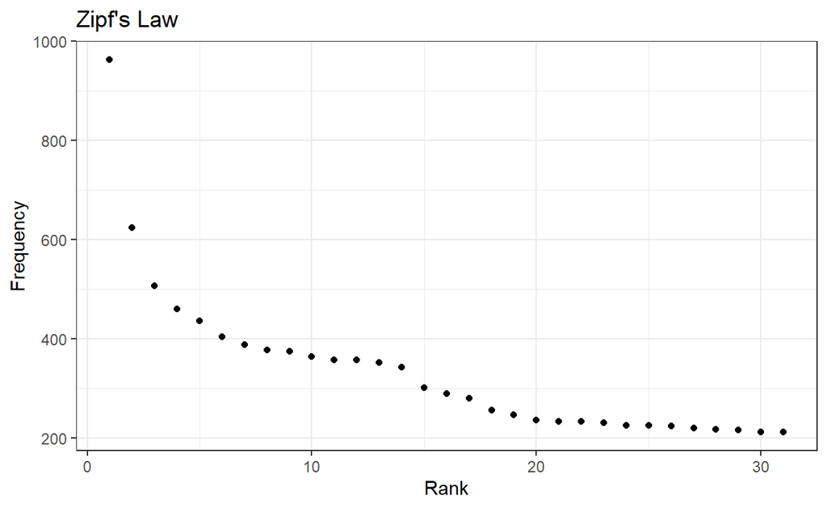

```r
ggplot(word_counts, mapping = aes(x = Rank, y = Frequency)) +
  geom_point() +
  labs(title = "Zipf's Law", x = "Rank", y = "Frequency") +
  theme_bw()
```

On initial review, I have successfully reduced the sparsity from over 99$ to ~90%. But that’s still quite a sparsity percentage. I could drop terms found in the updated word count list such as “one”, “two” and “get”, if I’m sure they are not relevant to the context of my research.

## Feature Co-Occurrence Matrix

Now I can take a look at this network of feature co-occurrences:

```r
# create fcm from dfm
smaller_fcm <- fcm(smaller_dfm)
# check the dimensions (i.e., the number of rows and the number of columnns)
# of the matrix we created
dim(smaller_fcm)
```

```
[1] 31 31
```

```r
# pull the top features
myFeatures <- names(topfeatures(smaller_fcm, 30))
# retain only those top features as part of our matrix
even_smaller_fcm <- fcm_select(smaller_fcm, pattern = myFeatures, selection = "keep")
# check dimensions
dim(even_smaller_fcm)
```

```
[1] 30 30
```

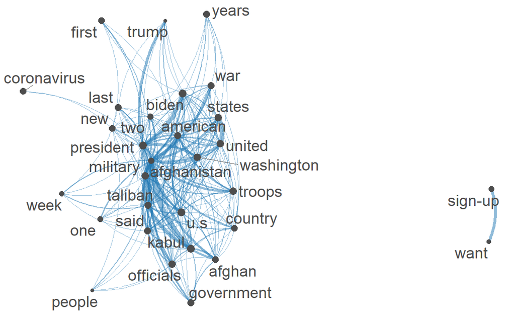

```r
# compute size weight for vertices in network
size <- log(colSums(even_smaller_fcm))
# create plot
textplot_network(even_smaller_fcm, vertex_size = size / max(size) * 3)
```

I am still not confident that the models I am creating are truly able to assist me with my original project topic, but this tutorial and process has definitely expanded my knowledge of the area of representing texts through these methods.